# Growth Exploration & Initial Models

Josh Carrell - Ph.D. Student | Forest Sciences - Colorado State University

Last Update: April 06, 2025

```r
library(tidyverse)
library(lme4)
library(DT)
# Data prepped for competition indexes
load("D:/Projects/SubalpineTopoGrowth/data/growth_long/subalpine_non_spatial.RData")
df <- subalpine_non_spatial
names(df)
```

```
##  [1] "id"                "Plot"              "Spec"
##  [4] "dbh4"              "annual_ba_cm_2022" "ci_3"
##  [7] "dead"              "elevation"         "slope"
## [10] "aspect"            "soil_moisture"     "soil_temperature"
## [13] "air_temperature"   "relative_humidity" "moisture_class"
```

```r
df <- df %>%
  filter(annual_ba_cm_2022 > 0) %>%
  filter(dead == 0)
```

## Question & Hypotheses

1.How does soil moisture availability and competition influence subalpine tree growth?

Hypothesis 1: Tree growth will be greater in wetter sites particularly for species that are less tolerant of drought.

Hypothesis 2: Tree growth will be limited by not only soil moisture but an interaction with competition, with trees growth being suppressed in areas of low soil moisture availability and high competition.

## Data

```r
DT::datatable(df, class = 'cell-border stripe', rownames = F, filter = 'top',
              editable = T, extensions = 'Buttons', options = list(dom = 'Bfrtip',
                                                                   buttons = c("excel")))
```

| id | Plot | Spec | dbh4 | annual_ba_cm_2022 | ci_3 | dead | elevation | slope | aspect | soil_moisture | soil_temperature | air_temperature | relative_humidity | moisture_class |
| --- | --- | --- | --- | --- | --- | --- | --- | --- | --- | --- | --- | --- | --- | --- |
| MRS1_100 | MRS1 | PICO | 21.1 | 3.26716275330152 | 3.87 | 0 | 2900 | 5 | 90 | 3.25 | 4.9 | 4.3 | 56.9 | Xeric |
| MRS1_101 | MRS1 | PICO | 20.9 | 7.403474572385146 | 4.55 | 0 | 2900 | 5 | 90 | 3.25 | 4.9 | 4.3 | 56.9 | Xeric |
| MRS1_174 | MRS1 | PICO | 15.4 | 2.757977532534568 | 7.86 | 0 | 2900 | 5 | 90 | 3.25 | 4.9 | 4.3 | 56.9 | Xeric |
| MRS1_175 | MRS1 | PICO | 23.1 | 3.581313018042023 | 4.85 | 0 | 2900 | 5 | 90 | 3.25 | 4.9 | 4.3 | 56.9 | Xeric |
| MRS1_173 | MRS1 | PICO | 19.5 | 3.509320249038996 | 5.58 | 0 | 2900 | 5 | 90 | 3.25 | 4.9 | 4.3 | 56.9 | Xeric |
| MRS1_275 | MRS1 | PICO | 15 | 1.930715168717841 | 7.27 | 0 | 2900 | 5 | 90 | 3.25 | 4.9 | 4.3 | 56.9 | Xeric |
| MRS1_2 | MRS1 | PICO | 25.4 | 8.423153973355442 | 2.38 | 0 | 2900 | 5 | 90 | 3.25 | 4.9 | 4.3 | 56.9 | Xeric |
| MRS1_3 | MRS1 | PICO | 15.2 | 3.475287303692112 | 7.3 | 0 | 2900 | 5 | 90 | 3.25 | 4.9 | 4.3 | 56.9 | Xeric |
| MRS1_4 | MRS1 | PICO | 25.8 | 2.014488572648654 | 4.17 | 0 | 2900 | 5 | 90 | 3.25 | 4.9 | 4.3 | 56.9 | Xeric |
| MRS1_5 | MRS1 | PICO | 19.5 | 4.974045858391728 | 5.15 | 0 | 2900 | 5 | 90 | 3.25 | 4.9 | 4.3 | 56.9 | Xeric |

[output cut: 3121 more lines]

## Plots

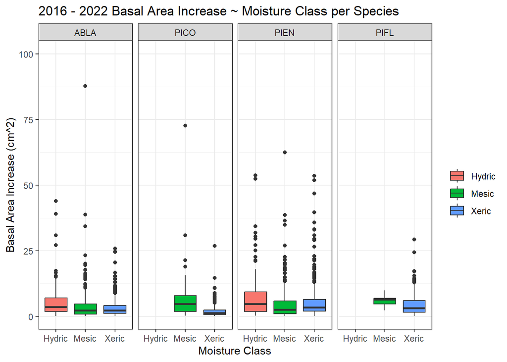

```r
ggplot(data = df) +
  geom_boxplot(mapping = aes(y = annual_ba_cm_2022, x = moisture_class, fill = moisture_class)) +
  theme_bw() +
  ylim(c(0,100)) +
  labs(y = "Basal Area Increase (cm^2)",
       x = "Moisture Class",
       fill = "",
       title = "2016 - 2022 Basal Area Increase ~ Moisture Class per Species") +
  facet_grid(~Spec)
```

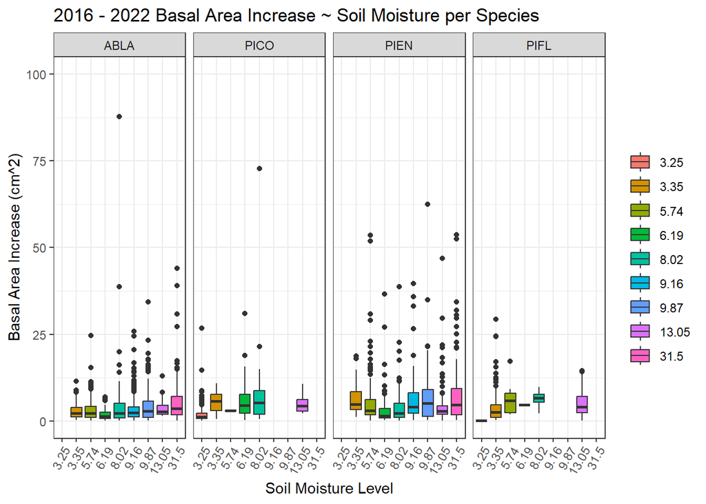

```r
ggplot(data = df) +
  geom_boxplot(mapping = aes(y = annual_ba_cm_2022, x = as.factor(soil_moisture), fill = as.factor(soil_moisture))) +
  theme_bw() +
  theme(axis.text.x = element_text(angle = 60, hjust=1)) +
  ylim(c(0,100)) +
  labs(y = "Basal Area Increase (cm^2)",
       x = "Soil Moisture Level",
       fill = "",
       title = "2016 - 2022 Basal Area Increase ~ Soil Moisture per Species") +
  facet_grid(~Spec)
```

## Linear Models

```r
mod_lm <- lm(annual_ba_cm_2022 ~ soil_moisture + Spec, data = df)
summary(mod_lm)
```

```
##
## Call:
## lm(formula = annual_ba_cm_2022 ~ soil_moisture + Spec, data = df)
##
## Residuals:
##     Min      1Q  Median      3Q     Max
##  -7.128  -2.722  -1.507   0.960 102.409
##
## Coefficients:
##               Estimate Std. Error t value Pr(>|t|)
## (Intercept)     2.7243     0.2473  11.015  < 2e-16 ***
## soil_moisture   0.1015     0.0143   7.096 1.59e-12 ***
## SpecPICO       -0.4173     0.3244  -1.286   0.1984
## SpecPIEN        1.4724     0.2609   5.644 1.81e-08 ***
## SpecPIFL        1.0854     0.4542   2.390   0.0169 *
## ---
## Signif. codes:  0 '***' 0.001 '**' 0.01 '*' 0.05 '.' 0.1 ' ' 1
##
## Residual standard error: 6.197 on 3126 degrees of freedom
## Multiple R-squared:  0.04188,    Adjusted R-squared:  0.04066
## F-statistic: 34.16 on 4 and 3126 DF,  p-value: < 2.2e-16
```

- Basal Area increases .10 cm^2 per 1 unit increase in soil moisture level. Significant.
- Species differ in mean growth from reference (ABLA).

```r
mod_lm_int <- lm(annual_ba_cm_2022 ~ soil_moisture * Spec, data = df)
summary(mod_lm_int)
```

```
##
## Call:
## lm(formula = annual_ba_cm_2022 ~ soil_moisture * Spec, data = df)
##
## Residuals:
##     Min      1Q  Median      3Q     Max
##  -8.497  -2.809  -1.261   0.960 102.329
##
## Coefficients:
##                        Estimate Std. Error t value Pr(>|t|)
## (Intercept)             2.99067    0.30109   9.933  < 2e-16 ***
## soil_moisture           0.07824    0.02078   3.764  0.00017 ***
## SpecPICO               -3.97049    0.67345  -5.896 4.13e-09 ***
## SpecPIEN                1.15424    0.43195   2.672  0.00758 **
## SpecPIFL                0.87874    0.84351   1.042  0.29760
## soil_moisture:SpecPICO  0.82020    0.13521   6.066 1.47e-09 ***
## soil_moisture:SpecPIEN  0.02743    0.02902   0.945  0.34458
## soil_moisture:SpecPIFL  0.01555    0.08925   0.174  0.86170
## ---
## Signif. codes:  0 '***' 0.001 '**' 0.01 '*' 0.05 '.' 0.1 ' ' 1
##
## Residual standard error: 6.164 on 3123 degrees of freedom
## Multiple R-squared:  0.05307,    Adjusted R-squared:  0.05094
## F-statistic:    25 on 7 and 3123 DF,  p-value: < 2.2e-16
```

- Very small but significant influence of soil moisture on basal area increase.

```r
mod_lm_comp <- lm(annual_ba_cm_2022 ~ soil_moisture + ci_3 + Spec, data = df)
summary(mod_lm_comp)
```

```
##
## Call:
## lm(formula = annual_ba_cm_2022 ~ soil_moisture + ci_3 + Spec,
##     data = df)
##
## Residuals:
##     Min      1Q  Median      3Q     Max
##  -7.859  -2.609  -0.997   0.942 100.579
##
## Coefficients:
##                Estimate Std. Error t value Pr(>|t|)
## (Intercept)    5.826280   0.276571  21.066  < 2e-16 ***
## soil_moisture  0.095269   0.013424   7.097 1.57e-12 ***
## ci_3          -0.203843   0.009885 -20.621  < 2e-16 ***
## SpecPICO       0.444495   0.307248   1.447  0.14808
## SpecPIEN       0.697858   0.247655   2.818  0.00486 **
## SpecPIFL      -0.502045   0.433086  -1.159  0.24645
## ---
## Signif. codes:  0 '***' 0.001 '**' 0.01 '*' 0.05 '.' 0.1 ' ' 1
##
## Residual standard error: 5.815 on 3125 degrees of freedom
## Multiple R-squared:  0.1566, Adjusted R-squared:  0.1553
## F-statistic: 116.1 on 5 and 3125 DF,  p-value: < 2.2e-16
```

- .10 increase in Basal Area per 1 unit increase in soil moisture.
- .2 decrease in Basal Area increase per 1 unit increase in competition.
- Species differ in significance and amount of increase when compared to reference species (ABLA).

## Mixed model with Plot as random effect

```r
mod_lmer <- lmer(annual_ba_cm_2022 ~ ci_3 + soil_moisture * Spec + dbh4 + (1 | Plot), data = df)
summary(mod_lmer)
```

```
## Linear mixed model fit by REML ['lmerMod']
## Formula: annual_ba_cm_2022 ~ ci_3 + soil_moisture * Spec + dbh4 + (1 |
##     Plot)
##    Data: df
##
## REML criterion at convergence: 19039.8
##
## Scaled residuals:
##     Min      1Q  Median      3Q     Max
## -4.0893 -0.3142 -0.0429  0.2004 17.8692
##
## Random effects:
##  Groups   Name        Variance Std.Dev.
##  Plot     (Intercept)  1.507   1.228
##  Residual             25.236   5.024
## Number of obs: 3131, groups:  Plot, 9
##
## Fixed effects:
##                         Estimate Std. Error t value
## (Intercept)            -1.468227   0.775725  -1.893
## ci_3                    0.002937   0.011174   0.263
## soil_moisture          -0.014737   0.054077  -0.273
## SpecPICO               -4.338846   1.377371  -3.150
## SpecPIEN               -0.439076   0.362813  -1.210
## SpecPIFL               -5.490205   0.888139  -6.182
## dbh4                    0.441940   0.013811  31.999
## soil_moisture:SpecPICO  0.234974   0.194160   1.210
## soil_moisture:SpecPIEN  0.030971   0.023738   1.305
## soil_moisture:SpecPIFL  0.390697   0.093485   4.179
##
## Correlation of Fixed Effects:
##             (Intr) ci_3   sl_mst SpPICO SpPIEN SpPIFL dbh4   s_:SPIC s_:SPIE
## ci_3        -0.340
## soil_moistr -0.719 -0.011
## SpecPICO    -0.262 -0.036  0.216
## SpecPIEN    -0.210  0.022  0.171  0.119
## SpecPIFL    -0.119 -0.054  0.134  0.196  0.143
## dbh4        -0.293  0.576 -0.053 -0.087 -0.104 -0.145
## sl_ms:SPICO  0.209  0.033 -0.173 -0.937 -0.012 -0.151 -0.004
## sl_ms:SPIEN  0.175  0.006 -0.224 -0.099 -0.785 -0.127  0.013  0.053
## sl_ms:SPIFL  0.068  0.057 -0.116 -0.159 -0.012 -0.856  0.062  0.155   0.109
```

This model:

- Controls for competition (ci_3)
- Allows species-specific responses to soil moisture
- Accounts for tree size (dbh4)
- Includes plot-level random intercepts (more useful when repeat measures will be included)

Results:

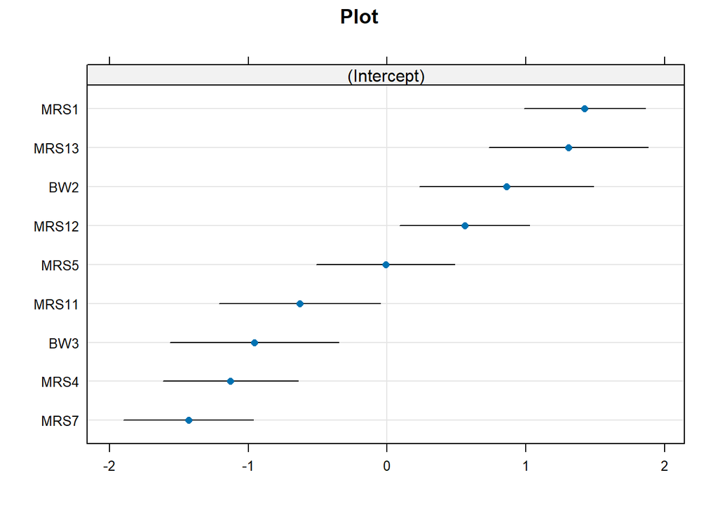

```r
lattice::dotplot(ranef(mod_lmer, condVar = TRUE))
```

```r
mod_lmer_ci_sm <- lmer(annual_ba_cm_2022 ~ ci_3 * soil_moisture + Spec + dbh4 + (1 | Plot), data = df)
summary(mod_lmer_ci_sm)
```

```
## Linear mixed model fit by REML ['lmerMod']
## Formula: annual_ba_cm_2022 ~ ci_3 * soil_moisture + Spec + dbh4 + (1 |
##     Plot)
##    Data: df
##
## REML criterion at convergence: 19047.1
##
## Scaled residuals:
##     Min      1Q  Median      3Q     Max
## -4.0171 -0.3088 -0.0366  0.1792 18.1081
##
## Random effects:
##  Groups   Name        Variance Std.Dev.
##  Plot     (Intercept)  1.195   1.093
##  Residual             25.276   5.028
## Number of obs: 3131, groups:  Plot, 9
##
## Fixed effects:
##                     Estimate Std. Error t value
## (Intercept)        -2.267607   0.695065  -3.262
## ci_3                0.032724   0.014394   2.274
## soil_moisture       0.076502   0.048595   1.574
## SpecPICO           -2.531488   0.471768  -5.366
## SpecPIEN           -0.188438   0.223319  -0.844
## SpecPIFL           -2.217245   0.457090  -4.851
## dbh4                0.431744   0.013868  31.133
## ci_3:soil_moisture -0.003742   0.001039  -3.601
##
## Correlation of Fixed Effects:
##             (Intr) ci_3   sl_mst SpPICO SpPIEN SpPIFL dbh4
## ci_3        -0.399
## soil_moistr -0.692  0.181
## SpecPICO    -0.190  0.015  0.150
## SpecPIEN    -0.142  0.016  0.002  0.325
## SpecPIFL    -0.116  0.005  0.060  0.229  0.332
## dbh4        -0.311  0.369 -0.084 -0.263 -0.154 -0.176
## c_3:sl_mstr  0.154 -0.633 -0.288 -0.046  0.020 -0.018  0.117
```

This model:

- Includes and interaction between competition and soil moisture.

Results:

- When competition is low, trees respond positively to soil moisture (+0.07), however when competition increases, the positive effect of moisture becomes negative. At higher competition, soil moisture has negative impact on basal area increase (moisture alone can’t compensate for loss in other resources like light, space, nutrients).

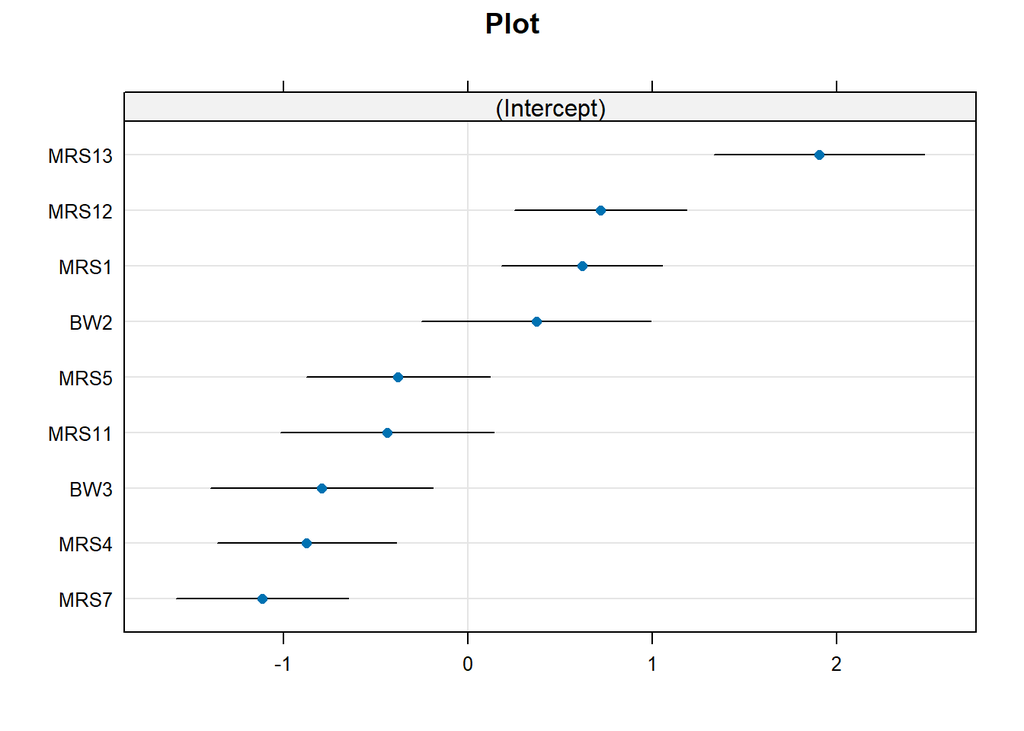

```r
lattice::dotplot(ranef(mod_lmer_ci_sm, condVar = TRUE))
```